# Actividad_Extracurricular_06_curso_de_git_y_github_PintoJuanFrancisco

### ESCUELA POLITÉCNICA NACIONAL

### FACULTAD DE INGENIERÍA EN SISTEMAS

### METODOS NUMERICOS ICCD412

### CURSO DE GIT Y GIT-HUB

*JUAN FRANCISCO PINTO ANDRANGO*

*GR1CC*

*FECHA DE ENTREGA 05 DE NOVIEMBRE DEL 2025*

[figure not shown]

## Conceptos claves entre Git y Git-Hub

### Git

*Para trabajar tanto con Git y GitHub se puede trabajar desde la terminal o con ciertas herramientas gráficas. Al principio se recomienda trabajar desde la terminal para poder reconocer y relacionar los comandos*

*En Git puede haber conflictos cuando se realizan modificaciones en las ramas que no se guardan correctamente. En ocasiones se pueden generar conflictos y es recomendable solucionarlos lo más rápido posible.*

### Git-Hub

*Git y Git-hub no es los mismo*

*Git es un sistema de control de versiones que permite trabajar con el código de manera segura, con diferentes ramas, y se trabaja de manera local en un computador*

*GitHub es una plataforma que trabaja con Git y que opera en la nube, donde el código se guarda en un servidor en el que más personas pueden interactuar*

*la sig URL muestra un repositorio con todos los comandos de Git-hub*

https://training.github.com/downloads/es_ES/github-git-cheat-sheet.pdf

## Referente al curso de git y git-hub

## Comandos importantes en la terminal de Git

*Git puede trabajar con ramas, también llamadas rama master o rama main. Además, un código sigue diferentes flujos por cada versión*

| Comando | Función |
| --- | --- |
| git-init | creación de un nuevo proyecto |
| git-status | ver qué pasa con los proyectos |
| git-add | guardar versión del proyecto |
| git-commit | comentario para guardar el proyecto |
| git-log | permite visualizar quién hizo los commits y ver el historial de edición |
| git-checkout | recupera archivos modificados cuando no se ejecuta el commit |
| git-reset | recuperación del archivo cuando no se ejecutó el commit |
| git-add + git-commit | guardar cambios del proyecto |
| git-log-graph | creación de una rama diferente del main |
| git config --global | configuraciones a nivel global |
| git-ignore | ignorar archivos que no están en la raíz |
| git-diff | visualizar los ficheros, configuraciones en proyectos, cambios en las ediciones |
| git-checkout head + git-log | indica dónde está la nueva cabeza del proyecto |
| git-reset | descarta los cambios, omite cambios |
| git-reset --hard + id | borrar archivos antiguos y recuperación de archivos de atrás o de adelante |
| git-reflog | historial completo de interacciones realizadas |
| git-tag | referencias a etiquetas importantes o puntos con referencia a versiones antiguas |
| git-add | añade todos los ficheros recién modificados en la raíz |
| git-branch | creación y ubicación en la rama |
| git-switch + nombre de la rama | moverse entre ramas main y secundarias |
| git-switch main | moverme a la rama principal |
| git-merge | función de adjuntar las ramas |
| git-stash | guardar un trabajo incompleto con un commit de manera temporal |
| git-stash pop | continuar desarrollando la actividad incompleta |
| git-stash list | ver archivos en los que se estuvo trabajando |
| git-stash drop | eliminación de stash incompletos |
| git-diff login | ver los cambios de cada rama |
| git-merge login | exportar cambios entre ramas main y secundarias |
| git-branch -d login | elimina las ramas después de la exportación |

### Comandos para Git-hub

##### comandos para sincronizar los cambios de Git y Git-hub

*En git-hub existen repositorios publicos y privados. En este curso se trabajo con un repositorio publico a manera de repositorio personal*

*URL para ver un repositorio con todos los comandos que relacionan a Git con Git-hub*

https://docs.github.com/es

https://docs.github.com/es/get-started/writing-on-github

##### Tabla con los comandos mas importantes de Git-Hub

| Comando | Descripcion o Funcion |
| --- | --- |
| git-push | para guardar copiar de un repositorio |
| git-pull | se descarga el historial y los cambios de un repositorio |
| git-fetch | se descrga el historioal sin cambios de un repositorio |
| git-clone | se usa para descargar o clonar un repositorio |
| git-clone + URL | descarga automaticamente desde la terminal |
| git-fork | clona el repositorio en un equipo local |
| sincronizar un fork | ver todas las versiones los archivos del repositorio |

##### Heramientos graficas para manejar Git y Git-hub

### Git-Hub Desktop

*Aplicacion ofical de Git-hub creada para el trabajo en repositorias alojados en git-hub posee una interfaz simple con funciones comunes como los commit, push, pull, branch, merge*

[figure not shown]

### GitKraken

*Herramiento independiente de Git-hub, conexion con multiples plataformas como Git-hub, Git-lab, Bitbucket. Ideal para el trabajo con diferentesservicion y equipos. Tiene una interfaz avanzada y visual muestra las ramas, mergere, commtis con diferentes lideas de colores. Recomendable para proyectos a gran escala o colaborativos*

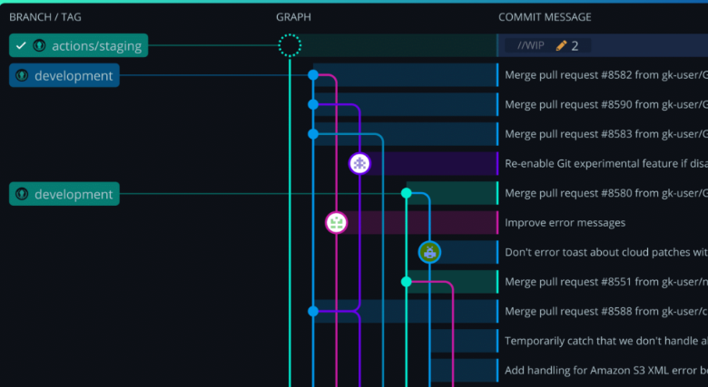

[figure not shown]

[figure not shown]

*Aqui el certificado tenia un costo y ya no tenia dinero para pagarlo :(*

# link del repositorio de git-hub

https://github.com/JuanfranPinto/Metodos-Numericos-